# Wordcloud2 introduction

2018-01-03

This is an introduction to `wordcloud2` package. This package provides an HTML5 interface to wordcloud for data visualization. [Timdream’s wordcloud2.js](https://github.com/timdream/wordcloud2.js) is used in this package.

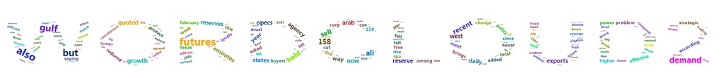

This document show two main function in `Wordcloud2`:

1. `wordcloud2`: provide traditional wordcloud with HTML5
2. `letterCloud`: provide wordcloud with selected word(letters).

### install wordcloud2

You may have installed this package. Well, I still want to leave these codes here for installing.

```r
require(devtools)
install_github("lchiffon/wordcloud2")
```

### `wordlcoud2` function

You can use wordcloud directly:

```r
library(wordcloud2)
wordcloud2(data = demoFreq)
```

[interactive chart not shown]

`demoFreq` is a data.frame including word and freq in each column.

```r
head(demoFreq)
```

```
##          word freq
## oil       oil   85
## said     said   73
## prices prices   48
## opec     opec   42
## mln       mln   31
## the       the   26
```

### Parameters

- `data`
- A data frame including word and freq in each column
- `size`
- Font size, default is 1. The larger size means the bigger word.
- `fontFamily`
- Font to use.
- `fontWeight`
- Font weight to use, e.g. normal, bold or 600
- `color`
- color of the text, keyword ‘random-dark’ and ‘random-light’ can be used. color vector is also supported in this param
- `minSize`
- A character string of the subtitle
- `backgroundColor`
- Color of the background.
- `gridSize`
- Size of the grid in pixels for marking the availability of the canvas the larger the grid size, the bigger the gap between words.
- `minRotation`
- If the word should rotate, the minimum rotation (in rad) the text should rotate.
- `maxRotation`
- If the word should rotate, the maximum rotation (in rad) the text should rotate. Set the two value equal to keep all text in one angle.
- `rotateRatio`
- Probability for the word to rotate. Set the number to 1 to always rotate.
- `shape`
- The shape of the “cloud” to draw. Can be a keyword present. Available presents are ‘circle’ (default), ‘cardioid’ (apple or heart shape curve, the most known polar equation), ‘diamond’ (alias of square), ‘triangle-forward’, ‘triangle’, ‘pentagon’, and ‘star’.
- `ellipticity`
- degree of “flatness” of the shape wordcloud2.js should draw.
- `figPath`
- A fig used for the wordcloud.
- `widgetsize`
- size of the widgets

#### Example1: use color and backgroundcolor

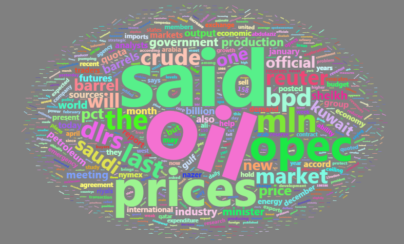

png

```r
wordcloud2(demoFreq, color = "random-light", backgroundColor = "grey")
```

#### Example2: use rotations

```r
wordcloud2(demoFreq, minRotation = -pi/6, maxRotation = -pi/6, minSize = 10,
  rotateRatio = 1)
```

[interactive chart not shown]

#### Example3: use figure file as a mask.

For example, `t.png` is A BIRD with black and white:

[figure not shown]

[figure not shown]

png

```r
figPath = system.file("examples/t.png",package = "wordcloud2")
wordcloud2(demoFreq, figPath = figPath, size = 1.5,color = "skyblue")
```

### `letterCloud` function

`letterCloud` provide the function to create a wordcloud with a word, like this:

[interactive chart not shown]

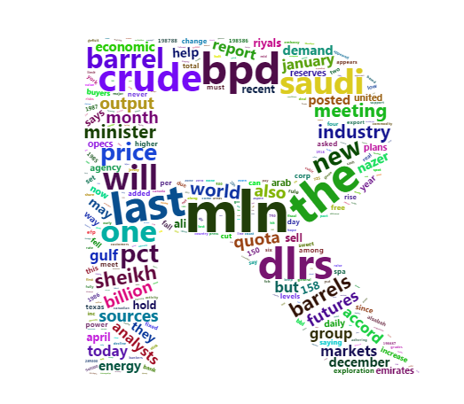

```r
letterCloud(demoFreq, word = "R", size = 2)
```

Or:

[interactive chart not shown]

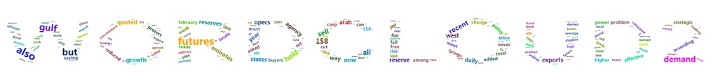

```r
letterCloud(demoFreq, word = "WORDCLOUD2", wordSize = 1)
```

**wordcloud with fig and letterCloud may disappeared in Rstudio Viewer, open into brower when you meet this bug**

#### Parameters

- `data`
- A data frame including word and freq in each column
- `word`
- A word to create shape for wordcloud.
- `wordSize`
- Parameter of the size of the word, default is 2.
- `letterFont`
- Letter font
- `...`
- Other parameters for wordcloud2 Go to wordcloud2 in the github to leave a comment or give this package a star.

### shiny

See Example:

```r
if(require(shiny)){
  library(wordcloud2)
   # Global variables can go here
   n <- 1

   # Define the UI
   ui <- bootstrapPage(
      numericInput('size', 'Size of wordcloud', n),
     wordcloud2Output('wordcloud2')
   )


   # Define the server code
   server <- function(input, output) {
      output$wordcloud2 <- renderWordcloud2({
      # wordcloud2(demoFreqC, size=input$size)
        wordcloud2(demoFreq, size=input$size)
      })
   }
   # Return a Shiny app object
   # Sys.setlocale("LC_CTYPE","chs") #if you use Chinese character
   ## Do not Run!
   shinyApp(ui = ui, server = server)
   }
```